# Tendencias en los clientes de casinos en Lima

Francesco Uccelli Meneses - 201810253, Alejandro Buitrago Zegarra - 201820079, Carlos Mazuelos Selem - 201810195, Santiago Madariaga Collado - 201810677

Barranco, 2019

UNIVERSIDAD DE INGENIERÍA Y TECNOLOGÍA

Profesor: Renom Andara, Jose Miguel

Curso: Estadística y Probabilidades

## Introducción

Las estadísticas y probabilidades se pueden encontrar en casi todos los lugares y situaciones, sin embargo existen lugares donde estas te pueden ayudar a ganar mucho dinero o hacer que lo pierdas todo, los casinos. Los casinos, sin lugar a duda, son uno de lugares más tentativos en los que se puede gastar muchísimo dinero, a pesar de todo los clientes van siempre con esperanza de poder ganar. El poker, la ruleta, los dados, las máquinas tragamonedas y muchos juegos más del casino son en los cuales las personas pierden más dinero. Pero, ¿las personas realmente saben cuales son sus probabilidades de salir victoriosos? Debido a estas cuestiones decidimos realizar un trabajo de investigación de campo y análisis de los datos recolectados de este mismo. A continuación se podrá ver a más detalle los objetivos planteados en esta investigación, datos sobre la población objetivo y la muestra a tomar. Además se podrá ver específicamente el método de recolección de datos y las preguntas que se les hará a la muestra seleccionada.

## Datos de la investigación a realizar

Los principales objetivos de esta investigación son dos. En primer lugar, conocer más sobre los perfiles de los clientes de los casinos y cómo son sus resultados normalmente. En segundo lugar, ver si realmente los clientes del casino saben cuales son sus probabilidades de salir victoriosos y con qué monto de dinero se conforman.

Para la realización de este estudio nos interesan los jugadores de los casinos, ya sea dentro de este o fuera, como en la universidad o calle. Debido a esto, el tipo de muestreo en esta investigación será de tipo conglomerado. De tal forma que se calcula que la unidad muestral sea de aproximadamente 15 personas por casino, siendo el número de casinos que se visitan, la unidad muestras será de 60 personas, esto irá de la mano con las personas que podamos entrevistar fuera del casino para llegar a un total de 100 muestras.

La recolección de data para la investigación será realizada por nosotros mismos. Durante los tres próximos fines de semana iremos a cuatro casinos distintos y entrevistamos a las personas que se encuentran jugando en el casino. Nosotros también nos acercaremos a personas aleatorias para que nos llenen la encuesta. Para la recolección de datos, hemos propuesto las siguientes preguntas, las cuales creemos que nos pueden ayudar a llegar a un análisis de la situación.

## Planificación sobre recolección de datos

Nuestro plan consta básicamente en dos muestras, la primera será de personas que se encuentren dentro de diferentes casinos y que estén realizando apuestas en diferentes juegos o máquinas. La siguiente sería de personas aleatorias tanto alumnos de la universidad como gente aleatoria en diversos lugares.

En la muestra, que es la de personas que se encuentran realizando apuestas dentro del casino, tenemos pensado generar un Google form con las preguntas. De esta manera, podremos entregarles un celular o dispositivo electrónico para que rápidamente llenen la encuesta sin hacerles perder mucho tiempo. Además esto nos garantiza una recolección de datos ordenada y fácil de analizar. Este método nos servirá también para entrevistar a las personas aleatorias.

## Recolección de datos

La recolección se llevó a cabo mayoritariamente de forma virtual haciendo uso de redes sociales. Luego, se procedió a hacer la limpieza de datos muestra por muestra debido a que muchas respuestas estaban en diferentes unidades o respuestas incoherentes. Con todos los datos limpios, armamos un archivo csv para luego hacer unas gráficas que nos ayudarían a llegar a ciertas conclusiones relacionando variables. A continuación estas:

### 1. Tema delimitado

Características de los Jugadores de Casinos en Lima.

### 2. Problemática

Los casinos han sido por mucho tiempo pasatiempos destinados a un determinado nicho de la población, sin notorios cambios en su logística y atracciones, volviéndose poco atractivo a las nuevas generaciones (en comparación con las anteriores). Los casinos buscan tener un margen de ganancias óptimo, el cual no sea lo suficientemente grande como para que las personas no deseen jugar ya que nunca experimentaron la sensación de ganar. Sin embargo, varias personas sienten la necesidad de jugar y jugar (sin importar la cantidad de dinero que pierdan), siendo un transtorno psicológico llamado ludopatía. Éste transtorno es muchas veces subestimado, pero es un problema para las personas que lo padecen. Con nuestro trabajo de investigación buscamos encontrar relaciones entre las diferentes características de los jugadores, para así detectar ciertas tendencias e identificarlas.

### 3. Justificación

Decidimos analizar el tema propuesto y abarcar dicha problemática debido a que consideramos que no existe información clara y reciente sobre este tema, con nuestra investigación lograremos identificar patrones que servirán de guía para futuras investigaciones y para ayudar a las empresas a estar al tanto de las personas asistentes a estos centros de entretenimiento.

### 4. Objetivos

**Objetivos generales**

- Describir las edades más comunes de personas asistentes al casino
- Describir el presupuesto que los jugadores encuestados están acostumbrados a tener
- Explorar las diferencias que existen entre un jugador de edad avanzada a uno joven
- Encontrar el juego preferido y describir porque es este
- Determinar la existencia del balance entre el presupuesto y el valor esperado de la ganancia

**Objetivos específicos**

- Descubrir si existe una relación notable entre la frecuencia de asistencia al casino con el valor esperado de la ganancia
- Encontrar semejanzas entre jugadores asistentes al mismo casino
- Descubrir si la mayoría de jugadores estan enterados de las probabilidades reales de ganar en los juegos que ellos frecuentan
- Validar si existe un patrón de ludopatía en nuestra muestra.

### 5. Definición de variables

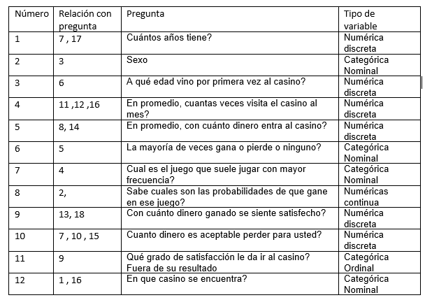

### 6. Preguntas de investigación:

**Preguntas descriptivas:**

1 ¿Cuál es el casino más visitado?

2 ¿Los integrantes de la muestra tienen idea de sus reales posibilidades de ganar?

3 ¿Quiénes tienen mayor interés en el casino (hombres o mujeres)?

4 ¿Cuál es el juego preferido?

5 ¿Cuál es el resultado más frecuente (ganar o perder)?

6 ¿A qué edad en promedio se empezo a ir al casino?

**Preguntas exploratorias:**

7 ¿Existe relación entre el presupuesto y la edad?

8 ¿La ganancia esperada tiene relación con el presupuesto?

9 ¿Existe relación entre la satisfaccion obtenida al jugar y el resultado general (ganar o perder frecuentemente) ?

**Preguntas inferenciales:**

11 ¿La frecuencia con la que una persona asiste al casino influye sobre su aceptación de pérdida?

12 ¿Las personas que asisten más de 5 veces al mes creen que ganan siempre?

**Preguntas predictivas:**

13 ¿Se puede conocer la satisfacción de un cliente sabiendo la frecuencia mensual?

14 ¿Es posible predecir la ganancia esperada de un jugador sabiendo su nivel de satisfacción al jugar?

**Preguntas mecanísticas**

15 ¿Cómo afecta a la tolerancia a perder el conocimiento sobre las probabilidades de ganar?

16 ¿De qué manera determina la edad la regularidad de los clientes?

**Preguntas casuales**

17 ¿Qué factores influyen en el juego preferido de los clientes?

18 ¿Qué factores determinan la ganancia máxima?

```r
library("graphics")

library("grid")
library("ggplot2") # beautiful graphs

library("ggthemes") # nice themes for ggplot2

library("ggbeeswarm") # "beeswarm" plots

library("cowplot") # arrrange graphs
library("pander") # nice tables

library("psych") # nice table of descriptive statistics
library("fdth") # carga la extensión fdth (para el calculo de distribución de frecuencias.
DF<-readr::read_csv("Casino.csv")
DF$`Ganancia maxima`<-round(DF$`Ganancia maxima`)
DF$`Perdida Maxima`<-round(DF$`Perdida Maxima`)
DF$Presupuesto<-round(DF$Presupuesto)
```

### Respuetas a las preguntas

**Preguntas descriptivas:**

- ¿Cuál es el casino más visitado?

```r
###<
a<-table(DF$Casino)
```

- ¿Los integrantes de la muestra tienen idea de sus reales posibilidades de ganar?

```r
na.omit(DF)
```

| Sexo | Edad | Frecuencia mensual | Edad de primera vez | Juego preferido | Resultado | Presupuesto | Probabilidad de Ganar | Ganancia maxima | Perdida Maxima | Satisfaccion | Casino |
| --- | --- | --- | --- | --- | --- | --- | --- | --- | --- | --- | --- |
| Mujer | 23 | 1 | 18 | ruleta | Ninguna | 70 | No | 100 | 20 | 4 | Fiesta |
| Hombre | 18 | 5 | 18 | ruleta | Pierde | 80 | No | 300 | 80 | 9 | Fiesta |
| Hombre | 18 | 5 | 18 | blackjack | Pierde | 50 | No | 50 | 30 | 7 | Fiesta |
| Hombre | 18 | 7 | 18 | ruleta | Pierde | 50 | No | 50 | 30 | 7 | Fiesta |
| Mujer | 18 | 1 | 18 | ruleta | Gana | 100 | No | 300 | 100 | 6 | Atlantic |
| Mujer | 18 | 3 | 18 | pocker | Pierde | 50 | 0.3 | 70 | 20 | 5 | Fiesta |
| Hombre | 18 | 3 | 18 | maquina tragamoneda | Pierde | 30 | 0.5 | 60 | 20 | 5 | Atlantic |
| Mujer | 18 | 1 | 18 | maquina tragamoneda | Pierde | 10 | 0.5 | 20 | 0 | 3 | Atlantic |
| Hombre | 18 | 0 | 18 | blackjack | Pierde | 30 | No | 40 | 10 | 1 | Fiesta |
| Hombre | 19 | 3 | 18 | pocker | Gana | 100 | No | 100 | 50 | 8 | Fiesta |

[output cut: 63 more lines]

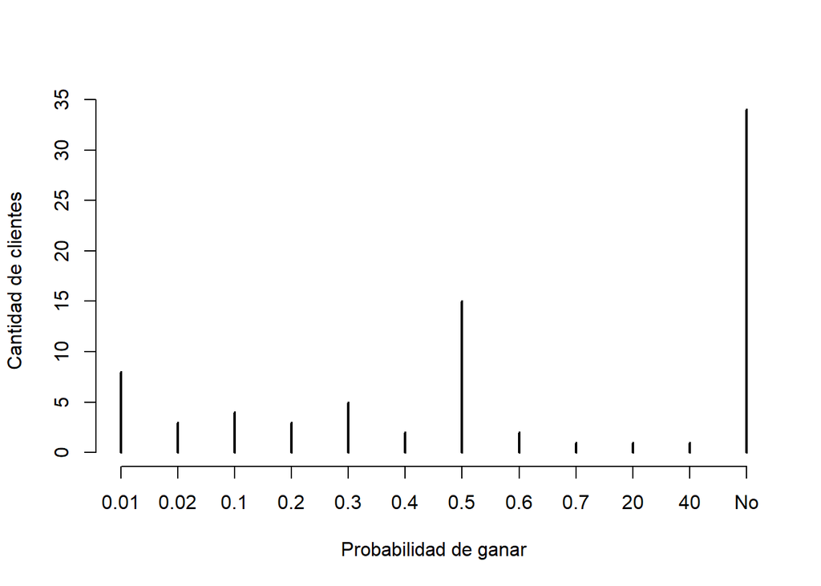

```r
al<-table(DF$`Probabilidad de Ganar`)
plot(al, xlab = "Probabilidad de ganar", ylab="Cantidad de clientes")
```

¿Quiénes tienen mayor interés en el casino (hombres o mujeres)?

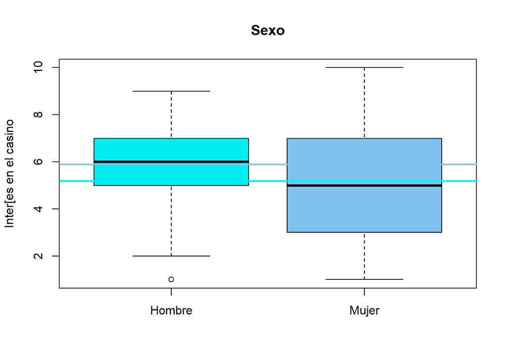

```r
sas_hombres<-DF[which(DF$Sexo=="Hombre"),]$Satisfaccion
sas_mujeres<-DF[which(DF$Sexo=="Mujer"),]$Satisfaccion
 boxplot(sas_hombres,sas_mujeres,col=c("cyan2","skyblue2"),main="Sexo",ylab="Inter[es en el casino", names=c("Hombre","Mujer"))
abline(h=mean(sas_hombres),col="skyblue2",lwd=2)
abline(h=mean(sas_mujeres),col="cyan2",lwd=2)
```

¿Cuál es el juego más jugado?

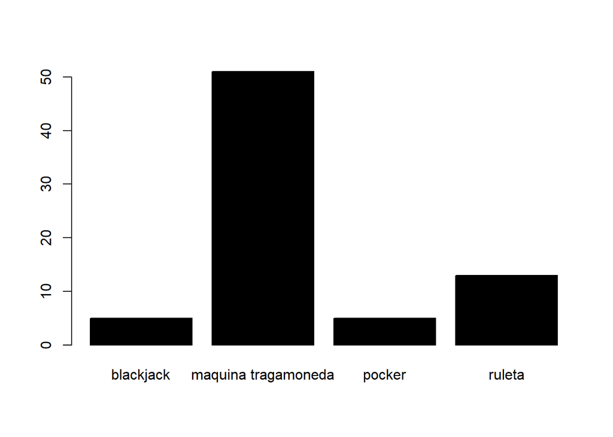

```r
a<-table(DF$`Juego preferido`)
barplot(a, col = "1")
```

```r
##
```

¿Cuál es el resultado más frecuente (ganar o perder)?

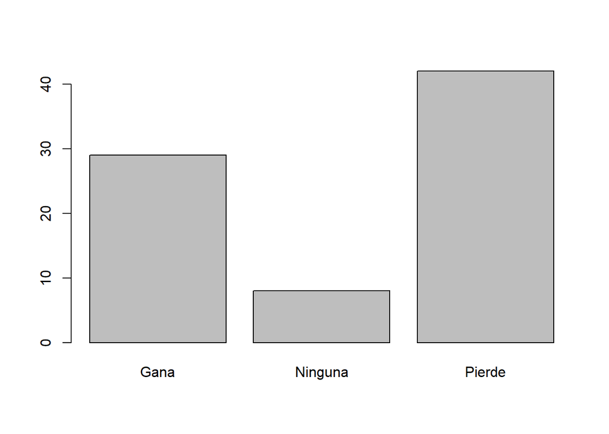

```r
a<-table(DF$Resultado)
barplot(a)
```

```r
###
```

¿A qué edad en promedio se empezo a ir al casino?

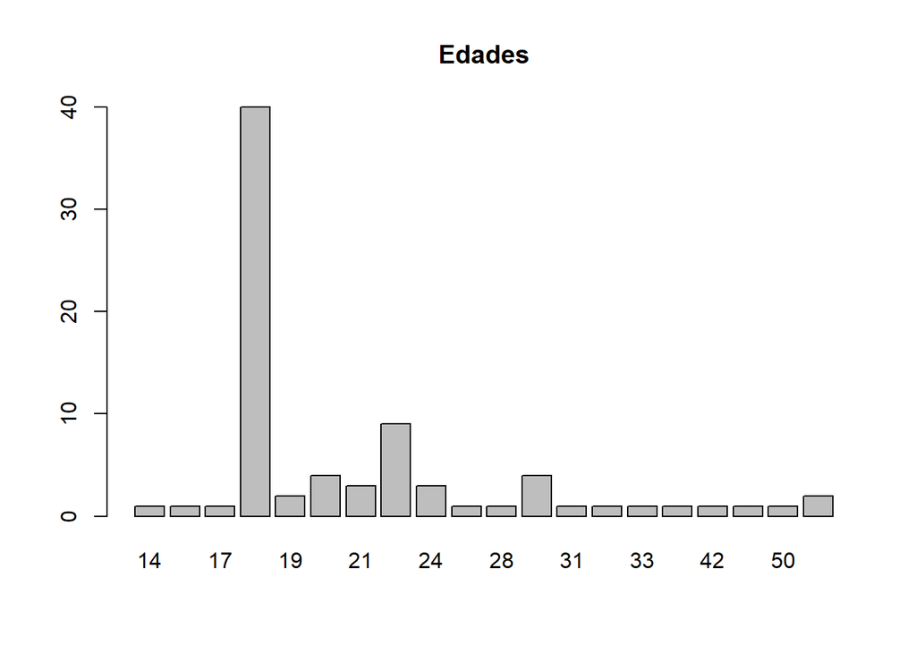

```r
barplot(table(DF$`Edad de primera vez`), main = "Edades")
```

### Respuesta a preguntas exploratorias:

¿Existe una relacion entre presupuesto y edad?

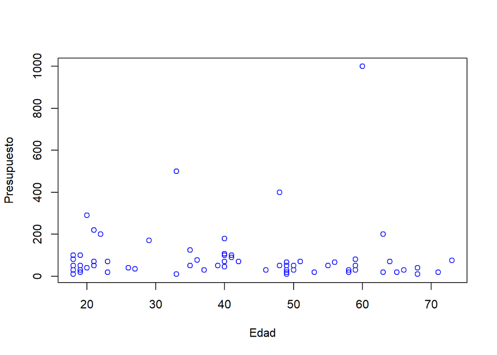

```r
plot(DF$Edad,DF$Presupuesto,xlab="Edad",ylab="Presupuesto",col="blue")
```

¿La ganancia esperada tiene relación con el presupuesto?

```r
table(DF$`Ganancia maxima`, DF$Presupuesto)
```

```
##
##        10 20 30 35 40 46 50 67 70 75 78 80 90 100 108 125 170 180 200 220
##   10    0  0  1  0  1  0  0  0  0  0  0  0  0   0   0   0   0   0   0   0
##   20    1  2  0  0  0  0  0  0  0  0  0  0  0   0   0   0   0   0   0   0
##   30    2  3  1  0  0  0  0  0  1  0  0  0  0   0   0   0   0   0   0   0
##   40    0  1  3  0  0  0  0  0  0  0  0  0  0   0   0   0   0   0   0   0
##   50    0  3  5  0  0  0  6  0  0  0  0  0  0   0   0   0   0   0   0   0
##   60    0  0  1  0  0  0  0  0  0  0  0  0  0   0   0   0   0   0   0   0
##   67    0  0  0  0  0  0  0  2  0  0  0  0  0   0   0   0   0   0   0   0
##   70    0  1  1  0  2  0  3  0  0  0  0  0  0   0   0   0   0   0   0   0
##   80    0  0  0  0  0  0  0  0  1  0  0  0  0   0   0   0   0   0   0   0
##   90    0  0  0  0  0  0  0  0  2  0  0  0  0   0   0   0   0   0   0   0
##   100   1  0  0  1  0  0  1  0  3  1  1  0  0   1   0   0   0   0   1   0
##   120   0  1  0  0  0  1  1  0  0  0  0  0  0   0   1   0   0   0   0   0
##   130   0  0  0  0  0  0  0  0  0  0  0  0  0   1   0   0   0   0   0   0
```

[output cut: 33 more lines]

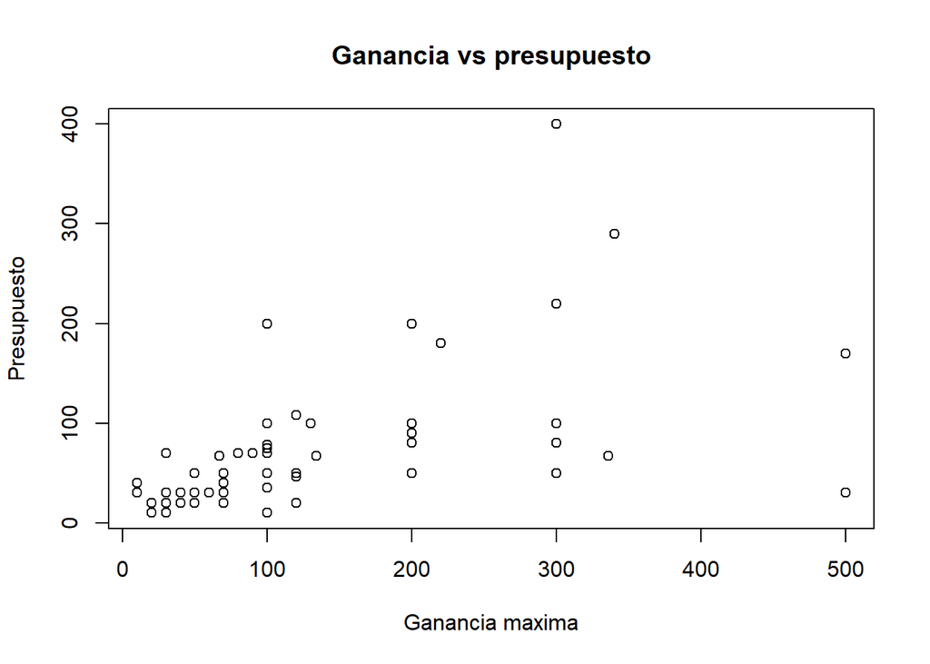

```r
plot(DF[which(DF$`Ganancia maxima`<800),]$`Ganancia maxima`, DF[which(DF$`Ganancia maxima`<800),]$Presupuesto,xlab="Ganancia maxima",ylab="Presupuesto", main="Ganancia vs presupuesto")
```

- ¿Existe relación entre la satisfaccion obtenida al jugar y el resultado general (ganar o perder frecuentemente) ?

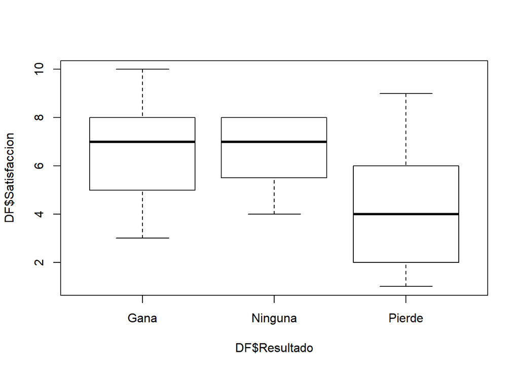

```r
boxplot(DF$Satisfaccion~DF$Resultado)
```

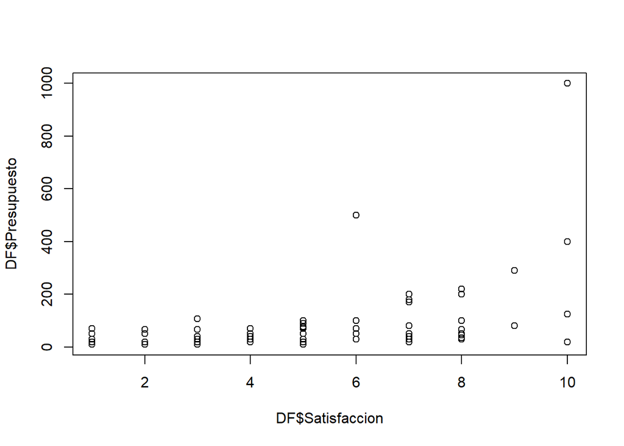

```r
plot(DF$Presupuesto~DF$Satisfaccion)
```

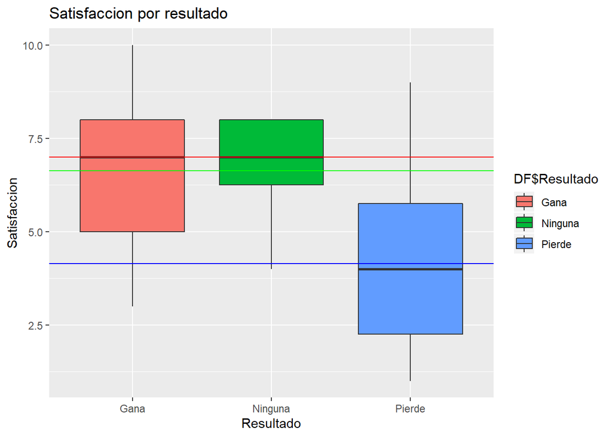

```r
ggplot(data = DF,aes(x=DF$Resultado,y=DF$Satisfaccion,fill=DF$Resultado))+geom_boxplot()+labs(title = "Satisfaccion por resultado",x="Resultado",y="Satisfaccion")+geom_hline(yintercept=7,color="red")+geom_hline(yintercept=6.625,color="green")+geom_hline(yintercept=4.142857,color="blue")
```

```r
mean(DF[which(DF$Resultado=="Gana"),]$Satisfaccion)
```

```
## [1] 7
```

```r
mean(DF[which(DF$Resultado=="Pierde"),]$Satisfaccion)
```

```
## [1] 4.142857
```

```r
mean(DF[which(DF$Resultado=="Ninguna"),]$Satisfaccion)
```

```
## [1] 6.625
```

### Preguntas inferenciales

¿Es coherente afirmar que un cliente con alta satisfacción asiste constantemente al casino y su perdida esperada es relativamente mayor?

Para responder la pregunta, usamos una grafica que represente la satisfaccion vs la frecuencia mensual de asistencia del jugador. Luego, por medio de la funcion geom_smooth, usamos el modelo de regresion lineal “lm” para intentar hallar una relación:

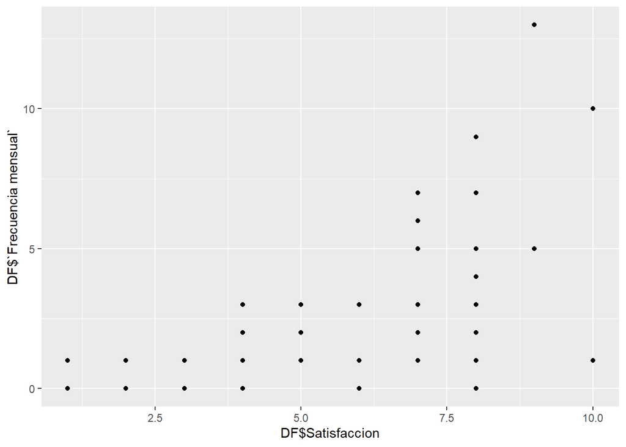

```r
k<-ggplot(data = DF, aes(x=DF$Satisfaccion,y=DF$`Frecuencia mensual`))
k+geom_point()
```

```r
mm <- lm(DF$`Frecuencia mensual`~DF$Satisfaccion)
summary(mm)
```

```
##
## Call:
## lm(formula = DF$`Frecuencia mensual` ~ DF$Satisfaccion)
##
## Residuals:
##     Min      1Q  Median      3Q     Max
## -4.6589 -1.3832 -0.2031  0.8924  8.0690
##
## Coefficients:
##                 Estimate Std. Error t value Pr(>|t|)
## (Intercept)     -1.62038    0.59299  -2.733  0.00779 **
## DF$Satisfaccion  0.72793    0.09925   7.334 1.92e-10 ***
## ---
## Signif. codes:  0 '***' 0.001 '**' 0.01 '*' 0.05 '.' 0.1 ' ' 1
##
## Residual standard error: 2.173 on 77 degrees of freedom
## Multiple R-squared:  0.4113, Adjusted R-squared:  0.4036
## F-statistic: 53.79 on 1 and 77 DF,  p-value: 1.924e-10
```

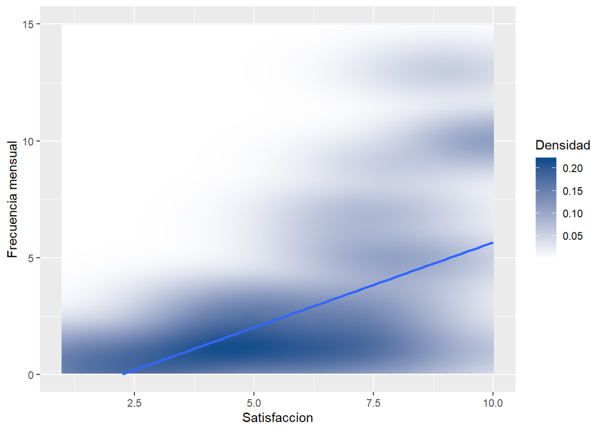

```r
satis<-subset(DF, DF$Satisfaccion>=6)
y=0.025
d=0.025

gg<-k +  stat_density2d(aes(fill = ..density..^0.5), geom = "tile", contour = FALSE, n = 200) +   scale_fill_continuous(low = "white", high = "dodgerblue4")
gg+geom_smooth(method = lm, se=FALSE)+ylim(0,15) + labs(x="Satisfaccion", y="Frecuencia mensual", fill="Densidad")
```

Con un $r^2$ de 0.4113, podemos señalar que existe una suficiente relación entre las variables.

Utilizaremos un nivel de confianza del 0.16 para hallar el estadístico de prueba:

```r
mean(satis$`Frecuencia mensual`)
```

```
## [1] 3.684211
```

```r
sd(satis$`Frecuencia mensual`)
```

```
## [1] 3.495984
```

```r
t.test(satis$`Frecuencia mensual`,mu=3,alternative = "g",conf.level = 0.16)
```

```
##
##  One Sample t-test
##
## data:  satis$`Frecuencia mensual`
## t = 1.2065, df = 37, p-value = 0.1176
## alternative hypothesis: true mean is greater than 3
## 16 percent confidence interval:
##  4.255873      Inf
## sample estimates:
## mean of x
##  3.684211
```

**Descripción:**

```r
nsatis<-subset(DF,DF$Satisfaccion<6)
nsatis<-nsatis[complete.cases(nsatis),]
muh<-(mean(nsatis$`Perdida Maxima`))
t.test(satis$`Perdida Maxima`,nsatis$`Perdida Maxima`,conf.level = 0.9)
```

```
##
##  Welch Two Sample t-test
##
## data:  satis$`Perdida Maxima` and nsatis$`Perdida Maxima`
## t = 3.9161, df = 40.549, p-value = 0.0003371
## alternative hypothesis: true difference in means is not equal to 0
## 90 percent confidence interval:
##  31.15545 78.13200
## sample estimates:
## mean of x mean of y
##  76.10526  21.46154
```

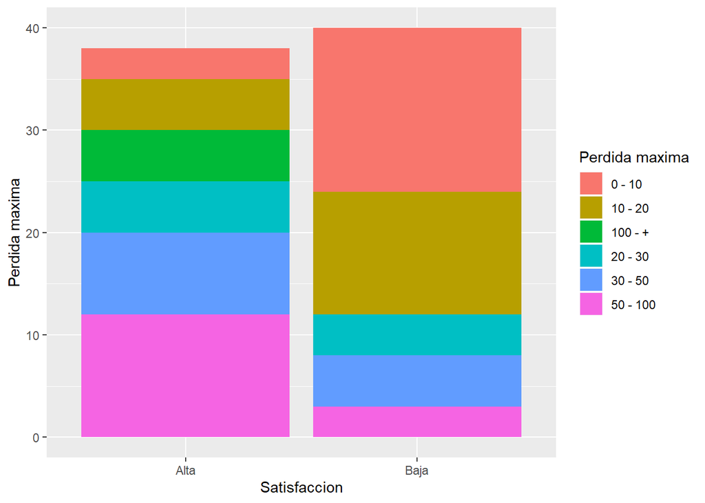

```r
DFC<-DF
DFC[which(DFC$Satisfaccion>=6),]$Satisfaccion<-"Alta"
DFC[which(DFC$Satisfaccion<6),]$Satisfaccion<-"Baja"
DFC[which(DFC$`Perdida Maxima`>100),]$`Perdida Maxima`<-175
DFC[which(DFC$`Perdida Maxima`<=100 & DF$`Perdida Maxima`>50),]$`Perdida Maxima`<-75
DFC[which(DFC$`Perdida Maxima`<=50 & DFC$`Perdida Maxima`>30),]$`Perdida Maxima`<-35
DFC[which(DFC$`Perdida Maxima`<=30 & DFC$`Perdida Maxima`>20),]$`Perdida Maxima`<-25
DFC[which(DFC$`Perdida Maxima`<=20 & DFC$`Perdida Maxima`>10),]$`Perdida Maxima`<-20
DFC[which(DFC$`Perdida Maxima`<=10),]$`Perdida Maxima`<-5

DFC[which(DFC$`Perdida Maxima`==175),]$`Perdida Maxima`<-"100 - +"
DFC[which(DFC$`Perdida Maxima`==75),]$`Perdida Maxima`<-"50 - 100"
DFC[which(DFC$`Perdida Maxima`==35),]$`Perdida Maxima`<-"30 - 50"
DFC[which(DFC$`Perdida Maxima`==25),]$`Perdida Maxima`<-"20 - 30"
DFC[which(DFC$`Perdida Maxima`==20),]$`Perdida Maxima`<-"10 - 20"
DFC[which(DFC$`Perdida Maxima`==5),]$`Perdida Maxima`<-"0 - 10"

estos<-as.data.frame(table(DFC$Satisfaccion, DFC$`Perdida Maxima`))

ggplot(data = estos, mapping = aes(x = estos$Var1, y = estos$Freq, fill = estos$Var2, order=estos$Var2)) + geom_bar(stat="identity", position="stack")+labs(x="Satisfaccion", y="Perdida maxima",fill="Perdida maxima")+theme_update()
```

¿Existe suficiente evidencia para señalar que la mayoría de personas que juegan a la maquina tragamonedas, son mayores que las que juegan los demas juegos?

Para responder esta pregunta, se preparará un data frame, con las edades como variable categórica:

```r
dfp<-DF
max(DF$Edad)
```

```
## [1] 73
```

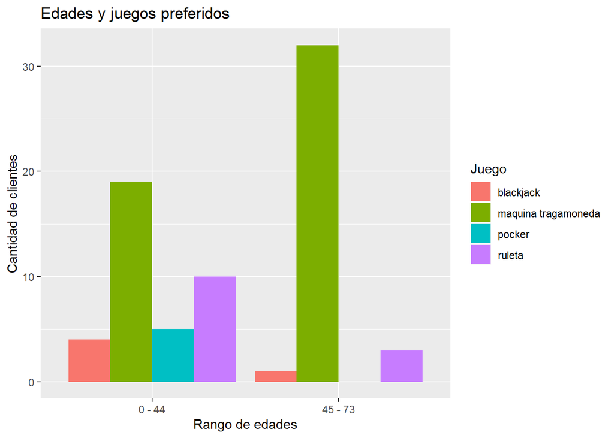

```r
dfp[which(dfp$Edad>44),]$Edad<-45
dfp[which(dfp$Edad<=44),]$Edad<-40

dfp[which(dfp$Edad==45),]$Edad<-"45 - 73"
dfp[which(dfp$Edad==40),]$Edad<-"0 - 44"
pref<-as.data.frame(table(dfp$Edad,dfp$`Juego preferido`))
ggplot(data = pref, mapping = aes(x = pref$Var1, y = pref$Freq, fill = pref$Var2))+geom_bar(stat="identity", position="dodge") + ylab("Cantidad de clientes") + xlab("Rango de edades") + ggtitle("Edades y juegos preferidos") + labs(fill="Juego")
```

Sacamos las medias de cada conjunto, de los que prefieren la maquina tragamoneda Y de los que prefieren los demás juegos

```r
nmaq<-subset(DF$Edad,DF$`Juego preferido` == "maquina tragamoneda")
maq<-subset(DF$Edad,DF$`Juego preferido` != "maquina tragamoneda")
```

Prueba de hipotesis $H[0]$: edad de no tragamonedoas = edad de tragamonedas $H[1]$: edad de no tragamonedoas =/ $ edad de tragamonedas

```r
t.test(nmaq,maq,conf.level = 0.9,alternative = "two.sided")
```

```
##
##  Welch Two Sample t-test
##
## data:  nmaq and maq
## t = 4.9913, df = 43.432, p-value = 1.02e-05
## alternative hypothesis: true difference in means is not equal to 0
## 90 percent confidence interval:
##  11.89427 23.97103
## sample estimates:
## mean of x mean of y
##  46.01961  28.08696
```

# ¿Es posible predecir la ganancia esperada de un jugador sabiendo su nivel de satisfaccion al jugar?

Grafica Ganancia Máxima vs Nivel de satisfacción al jugar

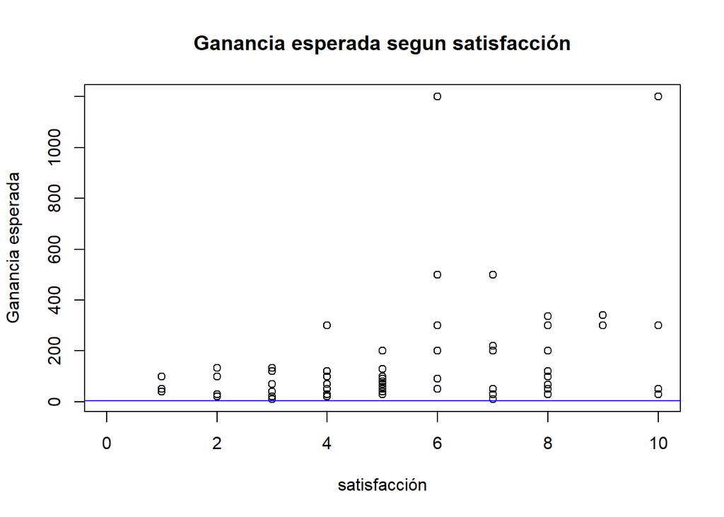

```r
satisfaccionaljugar<-DF$Satisfaccion[which(DF$`Ganancia maxima`<1500)]
gananciaesperada<-(DF$`Ganancia maxima`[which(DF$`Ganancia maxima`<1500)])
plot(satisfaccionaljugar,gananciaesperada
     ,main="Ganancia esperada segun satisfacción"
     ,ylab="Ganancia esperada"
     ,xlab="satisfacción"
     ,xlim=c(0,10))


abline(lm(satisfaccionaljugar~gananciaesperada), col="blue")
coeficiente_es<-c("r:",round(cor(satisfaccionaljugar, gananciaesperada),2))
legend(25, 70,legend=c(coeficiente_es),cex=0.8)
```

```r
summary(lm(gananciaesperada~satisfaccionaljugar))
```

```
##
## Call:
## lm(formula = gananciaesperada ~ satisfaccionaljugar)
##
## Residuals:
##     Min      1Q  Median      3Q     Max
## -230.13  -98.16  -33.87   39.29 1043.45
##
## Coefficients:
##                     Estimate Std. Error t value Pr(>|t|)
## (Intercept)            1.185     53.184   0.022  0.98229
## satisfaccionaljugar   25.894      9.006   2.875  0.00524 **
## ---
## Signif. codes:  0 '***' 0.001 '**' 0.01 '*' 0.05 '.' 0.1 ' ' 1
##
## Residual standard error: 192.8 on 76 degrees of freedom
## Multiple R-squared:  0.0981, Adjusted R-squared:  0.08623
## F-statistic: 8.266 on 1 and 76 DF,  p-value: 0.005236
```

# ¿Se puede conocer la satisfacción de un cliente sabiendo la frecuencia mensual?

```r
p1<-ggplot(data = DF, aes(x =  DF$Satisfaccion, y =DF$`Frecuencia mensual`))
```

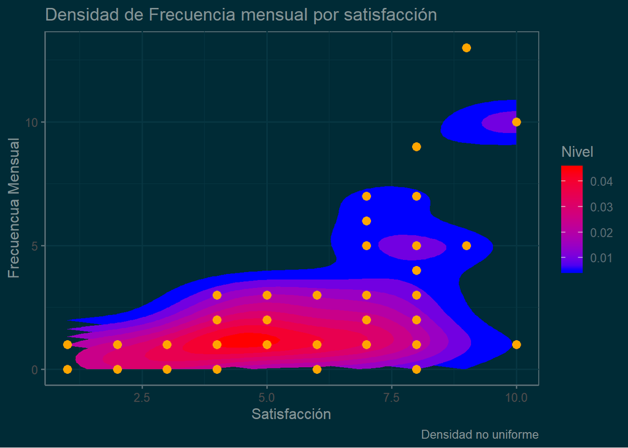

```r
p1 +
  stat_density_2d(aes(fill = ..level..), geom = "polygon") +  scale_fill_gradient(low = "blue", high = "red") +  labs(title ="Density Plot of Outcome by Predictor") + geom_point(color = "orange", size =3) + theme_solarized(light =  FALSE) + scale_color_solarized("blue") + labs(x="Satisfacción", y="Frecuencua Mensual", title = "Densidad de Frecuencia mensual por satisfacción", caption = "Densidad no uniforme", fill="Nivel")
```

```r
ax<-lm(DF$Satisfaccion~DF$`Frecuencia mensual`)
summary(ax)
```

```
##
## Call:
## lm(formula = DF$Satisfaccion ~ DF$`Frecuencia mensual`)
##
## Residuals:
##     Min      1Q  Median      3Q     Max
## -3.6849 -1.1624 -0.1199  1.3151  5.3151
##
## Coefficients:
##                         Estimate Std. Error t value Pr(>|t|)
## (Intercept)              4.11995    0.28098  14.663  < 2e-16 ***
## DF$`Frecuencia mensual`  0.56499    0.07703   7.334 1.92e-10 ***
## ---
## Signif. codes:  0 '***' 0.001 '**' 0.01 '*' 0.05 '.' 0.1 ' ' 1
##
## Residual standard error: 1.915 on 77 degrees of freedom
## Multiple R-squared:  0.4113, Adjusted R-squared:  0.4036
## F-statistic: 53.79 on 1 and 77 DF,  p-value: 1.924e-10
```

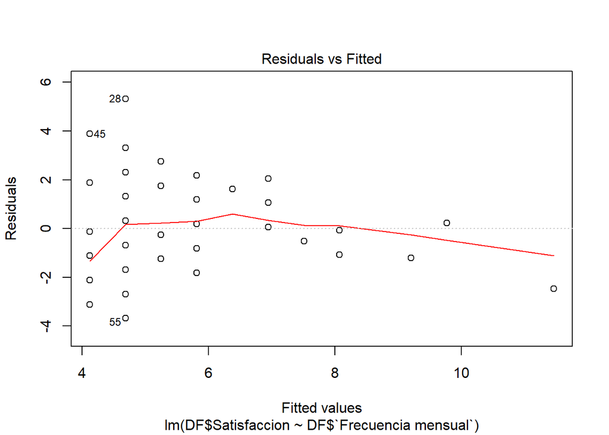

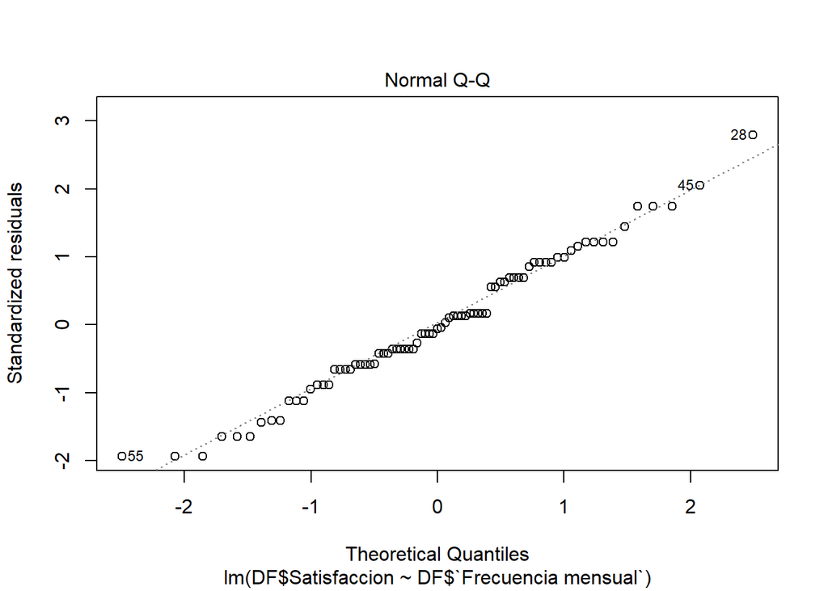

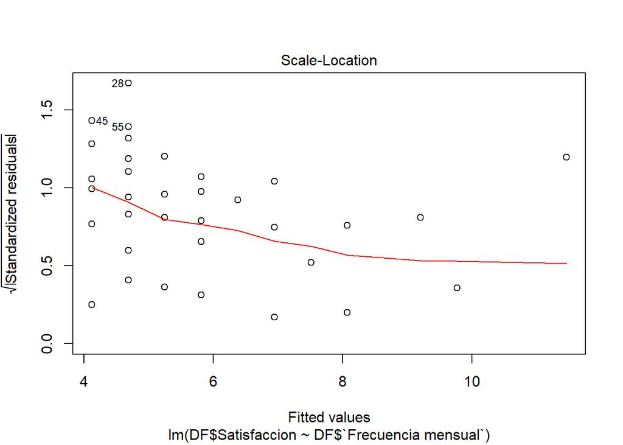

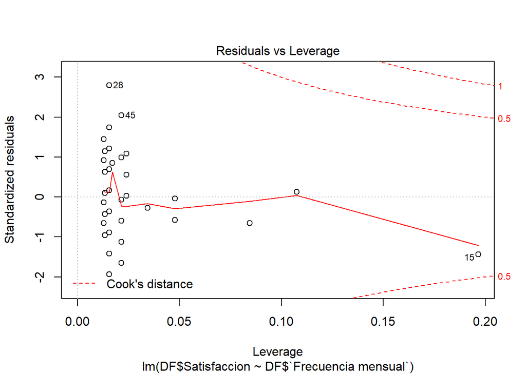

```r
plot(ax)
```

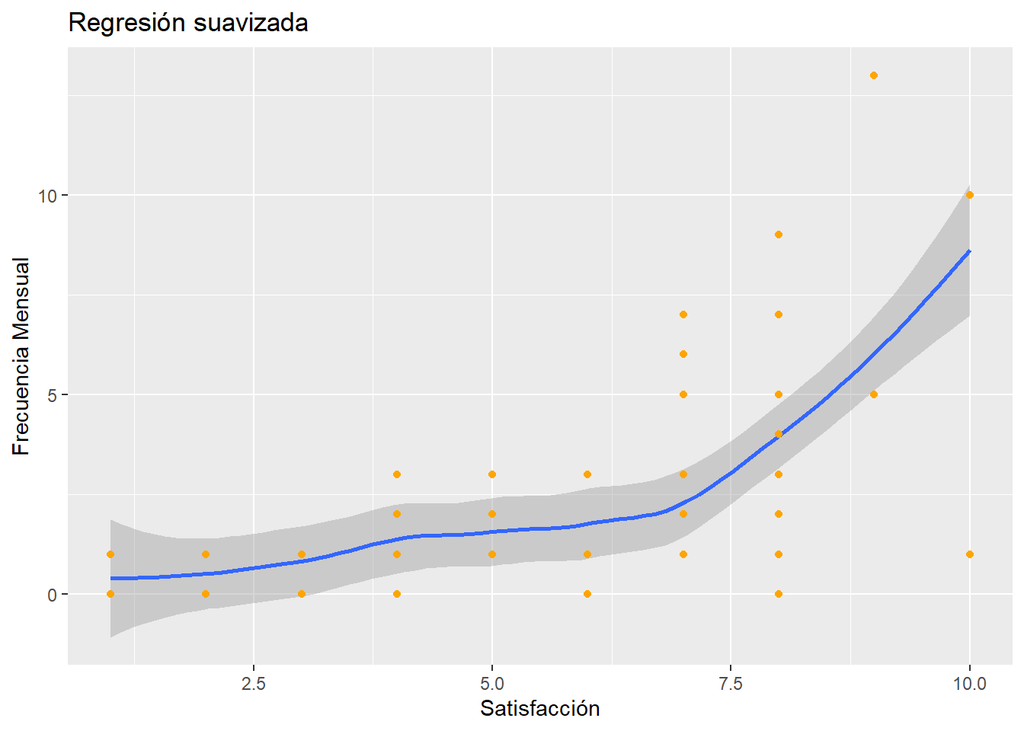

```r
p1 + geom_smooth() + geom_point(color = "orange") + labs(title="Regresión suavizada",x="Satisfacción",y="Frecuencia Mensual") +xlim(1,10)
```

```r
p1a<-loess(DF$`Frecuencia mensual`~DF$Satisfaccion, span = 0.1)
summary(p1a)
```

```
## Call:
## loess(formula = DF$`Frecuencia mensual` ~ DF$Satisfaccion, span = 0.1)
##
## Number of Observations: 79
## Equivalent Number of Parameters: NaN
## Residual Standard Error: NaN
## Trace of smoother matrix: NaN  (exact)
##
## Control settings:
##   span     :  0.1
##   degree   :  2
##   family   :  gaussian
##   surface  :  interpolate      cell = 0.2
##   normalize:  TRUE
##  parametric:  FALSE
## drop.square:  FALSE
```

```r
smp1a<-predict(p1a)
```

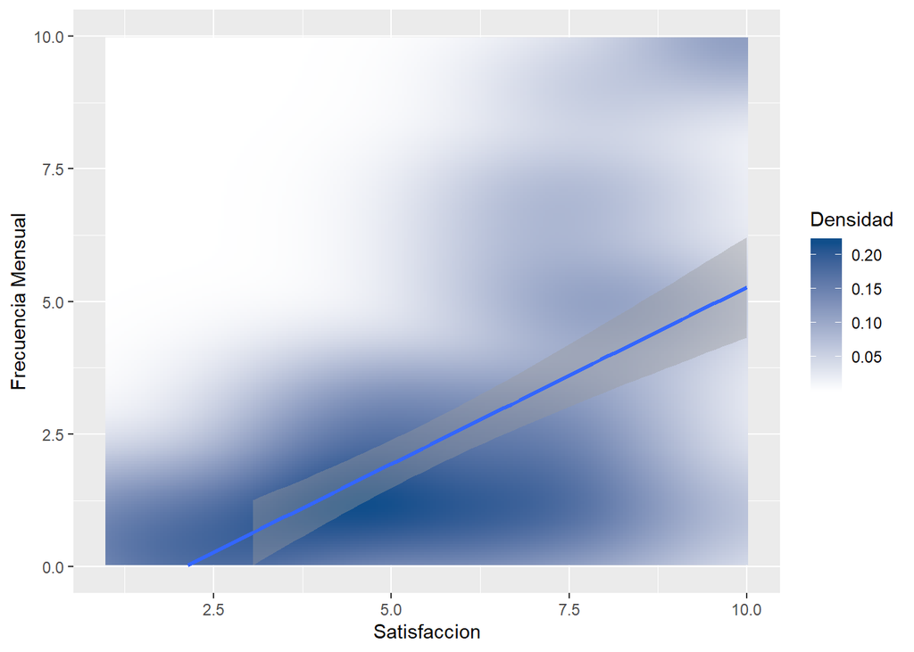

```r
library(ggplot2)
satisfaccionaljugar<-DF$Satisfaccion
frec<-DF$`Frecuencia mensual`
ggplot(data = DF,aes(x=satisfaccionaljugar,y=frec))+stat_density2d(aes(fill = ..density..^0.5), geom = "tile", contour = FALSE, n = 200) +   scale_fill_continuous(low = "white", high = "dodgerblue4") + geom_smooth(method = lm)+ylim(0,10)+labs(x="Satisfaccion",y="Frecuencia Mensual",fill="Densidad")
```

```r
summary(lm(DF$`Frecuencia mensual`~DF$Satisfaccion))
```

```
##
## Call:
## lm(formula = DF$`Frecuencia mensual` ~ DF$Satisfaccion)
##
## Residuals:
##     Min      1Q  Median      3Q     Max
## -4.6589 -1.3832 -0.2031  0.8924  8.0690
##
## Coefficients:
##                 Estimate Std. Error t value Pr(>|t|)
## (Intercept)     -1.62038    0.59299  -2.733  0.00779 **
## DF$Satisfaccion  0.72793    0.09925   7.334 1.92e-10 ***
## ---
## Signif. codes:  0 '***' 0.001 '**' 0.01 '*' 0.05 '.' 0.1 ' ' 1
##
## Residual standard error: 2.173 on 77 degrees of freedom
## Multiple R-squared:  0.4113, Adjusted R-squared:  0.4036
## F-statistic: 53.79 on 1 and 77 DF,  p-value: 1.924e-10
```

¿Es posible predecir la ganancia esperada de un jugador sabiendo su nivel de satisfaccion al jugar? Grafica Ganancia Esperada vs Nivel de satisfacción al jugar

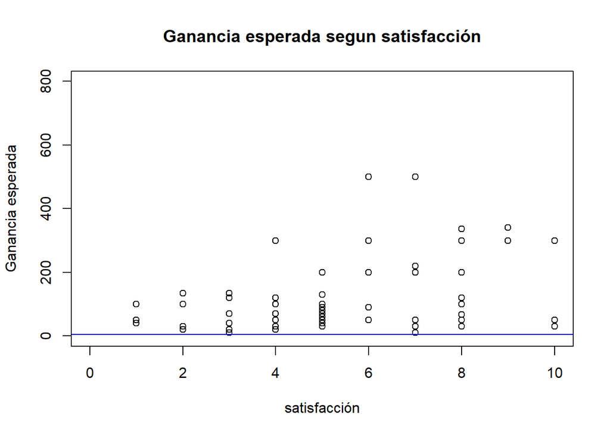

```r
satisfaccionaljugar<-DF$Satisfaccion[which(DF$`Ganancia maxima`<1500)]
gananciaesperada<-(DF$`Ganancia maxima`[which(DF$`Ganancia maxima`<1500)])
plot(satisfaccionaljugar,gananciaesperada
     ,main="Ganancia esperada segun satisfacción"
     ,ylab="Ganancia esperada"
     ,xlab="satisfacción"
     ,xlim=c(0,10)
,ylim=c(0,800))



abline(lm(satisfaccionaljugar~gananciaesperada), col="blue")
coeficiente_es<-c("r:",round(cor(satisfaccionaljugar, gananciaesperada),2))
legend(25, 70,legend=c(coeficiente_es),cex=0.8)
```

```r
summary(lm(gananciaesperada~satisfaccionaljugar))
```

```
##
## Call:
## lm(formula = gananciaesperada ~ satisfaccionaljugar)
##
## Residuals:
##     Min      1Q  Median      3Q     Max
## -230.13  -98.16  -33.87   39.29 1043.45
##
## Coefficients:
##                     Estimate Std. Error t value Pr(>|t|)
## (Intercept)            1.185     53.184   0.022  0.98229
## satisfaccionaljugar   25.894      9.006   2.875  0.00524 **
## ---
## Signif. codes:  0 '***' 0.001 '**' 0.01 '*' 0.05 '.' 0.1 ' ' 1
##
## Residual standard error: 192.8 on 76 degrees of freedom
## Multiple R-squared:  0.0981, Adjusted R-squared:  0.08623
## F-statistic: 8.266 on 1 and 76 DF,  p-value: 0.005236
```

## Preguntas macanísticas

15 ¿Cómo afecta a la tolerancia a perder el conocimiento sobre las probabilidades de ganar?

En esta pregunta se va a analizar si hay alguna relación entre la tolerancia a perder dinero en el casino y el conocimiento de las probabilidades de ganar. Lógicamente, si una persona sabe que sus probabilidades de ganar son bajas, debería de tolerar más la pérdida.

```r
probabilidad<- (DF$`Probabilidad de Ganar`)
tolerancias <- (DF$`Perdida Maxima`)
probabilidad
```

```
##  [1] "No"   "No"   "No"   "No"   "No"   "0.3"  "0.5"  "0.5"  "No"   "No"
## [11] "No"   "0.5"  "0.3"  "0.5"  "No"   "0.02" "No"   "0.4"  "0.5"  "0.6"
## [21] "No"   "0.5"  "No"   "40"   "0.2"  "0.3"  "No"   "0.5"  "0.5"  "No"
## [31] "0.1"  "0.5"  "No"   "No"   "No"   "No"   "0.5"  "0.1"  "0.01" "0.5"
## [41] "0.6"  "No"   "0.4"  "0.3"  "0.5"  "0.5"  "0.5"  "0.2"  "0.5"  "No"
## [51] "0.01" "0.01" "No"   "No"   "No"   "0.3"  "0.01" "0.01" "No"   "No"
## [61] "0.02" "0.7"  "No"   "No"   "20"   "No"   "0.1"  "0.01" "0.01" "No"
## [71] "No"   "No"   "No"   "0.2"  "No"   "0.1"  "0.02" "0.01" "No"
```

```r
tolerancias
```

```
##  [1]  20  80  30  30 100  20  20   0  10  50  30  50  40  20 100  10  20
## [18]  50 100 100  50  10  30  20 120 200  10 100  50  20  10  20  20 100
## [35]  50  70  10  50  50  30   0 100  50 168  67  50  10 100  NA  30  67
## [52]  20   0   0  50  50  10  10  70  20   0  20  30  67   0  20  30  70
## [69]  20 500  20 150  20  30  10  20   0  10  10
```

16 ¿De qué manera determina el casino la regularidad de los clientes?

En esta pregunta vmaos ha analizar si la edad de kis encuestados afecta la regularidad con la que van al casino. Esto se podría deber a diferentes niveles de estabilidad económica, tiempo libre, etc.

Por otro lado, en el capítulo 5 de la tésis “ESTUDIO SOBRE LA REPUTACIÓN PERCIBIDA POR LOS CLIENTES POTENCIALES, ENFOCADO EN LAS DIMENSIONES DE LA ÉTICA Y RESPONSABILIDAD CORPORATIVA, Y CALIDAD DEL SERVICIO EN LAS SALAS MÁS EXCLUSIVAS DEL SECTOR DE JUEGOS DE CASINOS Y MÁQUINAS TRAGAMONEDAS EN LOS DISTRITOS DE INDEPENDENCIA, SAN MIGUEL, MIRAFLORES, SAN ISIDRO, SANTIAGO DE SURCO, MAGDALENA Y LINCE”(CABRERA LEIVA, Will Jhino) se menciona el análisis de una pregunta relativamente parecida, la diferencia es que se divide la frecuencia y las edades de una manera diferente. Resaltando una gran mayoría de frecuencia en relación a los clientes entre 35 y 56 años.

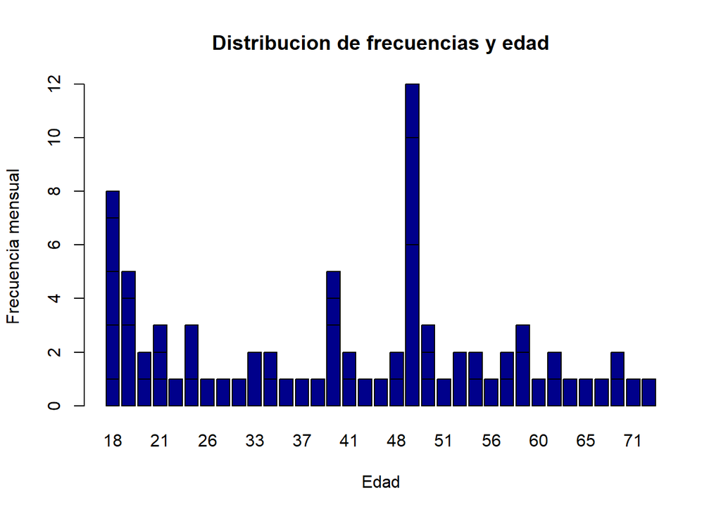

```r
mec1 <- table(DF$`Frecuencia mensual`,DF$Edad)
barplot(mec1, main="Distribucion de frecuencias y edad",
  xlab="Edad", col=c("darkblue"),ylab = "Frecuencia mensual")
```

```r
fiesta<-na.omit(DF$`Frecuencia mensual`[which(DF$Casino=="Fiesta")])
mean(fiesta)
```

```
## [1] 2.974359
```

```r
atlantic<-na.omit(DF$`Frecuencia mensual`[which(DF$Casino=="Atlantic")])
atlantic
```

```
##  [1]  1  3  1  2  1  3  1  9  1  5  2  1  1  1  0  2  1  1 10  2
```

```r
mean(atlantic)
```

```
## [1] 2.4
```

```r
ninguno<-na.omit(DF$`Frecuencia mensual`[which(DF$Casino=="Ninguno")])
mean(ninguno)
```

```
## [1] 0.6666667
```

## Preguntas casuales:

17 ¿Influye la edad en el juego preferido de los clientes?

Si bien anteriormente analizamos la relación entre la edad y la frecuencia de asitsencia al casino, en esta pregunta veremos si hay una relación entre la edad y el juego preferido de los clientes:

```r
edad<-na.omit(DF$Edad)
juego<-na.omit(DF$Juego)
```

18 ¿Qué factores determinan la ganancia máxima?

Dado, que nosotros conocemos teoria de probabilidades, si evlaumos las posibilidades de en este ejemplo:

Posibilidades de Duplicar tu dinero en porcentaje

Ruleta

```r
(17/36)*100
```

```
## [1] 47.22222
```

En máquina tragamonedas:

La mayoría de máquina de tragamonedas tienen un retorno de entre 80 y 95 céntimos de retorno por sol invertido. Sin embargo, dado que hay muchos premios distintos que ocurren con frecuencias muy diferentes, no se puede determinar la probabilidad de duplicar tu dinero.

En blackjack:

La probabilidad de ganar en este juego esta severmente influenciada por las regals con las que se juega, cada casino tiene diferentes reglas que beneficias más al jugador o a la casa.

Probabilidad de sacar blackjack, pago 3/2

```r
result <-4*16/choose(52,2)
result
```

```
## [1] 0.04826546
```

Probabilidad de ganar la mano Dada la gran cantidad de variables que entran en juego al calcular una sola mano lo calcularemos con lo que se sabe que tiene de ventaja casa en un juego general de blackjack que es 0.05 entonces :

Aproximados: Probabilidad de ganar:44 Probabilidad de de perder:48 Probabilidad de empatar: 8

## Preguntas macanísticas

15 ¿Cómo afecta a la tolerancia a perder el conocimiento sobre las probabilidades de ganar?

En esta pregunta se va a analizar si hay alguna relación entre la tolerancia a perder dinero en el casino y el conocimiento de las probabilidades de ganar. Lógicamente, si una persona sabe que sus probabilidades de ganar son bajas, debería de tolerar más la pérdida.

```r
probabilidad<- (DF$Probabilidad.de.Ganar)
tolerancias <- (DF$Perdida.Maxima)
probabilidad
```

[output not shown]

```r
tolerancias
```

[output not shown]

16 ¿De qué manera determina la la regularidad de los clientes?

En esta pregunta vmaos ha analizar si la edad de los encuestados afecta la regularidad con la que van al casino. Esto se podría deber a diferentes niveles de estabilidad económica, tiempo libre, etc.

Por otro lado, en el capítulo 5 de la tésis “ESTUDIO SOBRE LA REPUTACIÓN PERCIBIDA POR LOS CLIENTES POTENCIALES, ENFOCADO EN LAS DIMENSIONES DE LA ÉTICA Y RESPONSABILIDAD CORPORATIVA, Y CALIDAD DEL SERVICIO EN LAS SALAS MÁS EXCLUSIVAS DEL SECTOR DE JUEGOS DE CASINOS Y MÁQUINAS TRAGAMONEDAS EN LOS DISTRITOS DE INDEPENDENCIA, SAN MIGUEL, MIRAFLORES, SAN ISIDRO, SANTIAGO DE SURCO, MAGDALENA Y LINCE”(CABRERA LEIVA, Will Jhino) se menciona el análisis de una pregunta relativamente parecida, la diferencia es que se divide la frecuencia y las edades de una manera diferente. Resaltando una gran mayoría de frecuencia en relación a los clientes entre 35 y 56 años.

```r
mec1 <- table(DF$`Frecuencia mensual`,DF$Edad)
length(DF$`Frecuencia mensual`)
```

```
## [1] 79
```

```r
length(DF$Edad)
```

```
## [1] 79
```

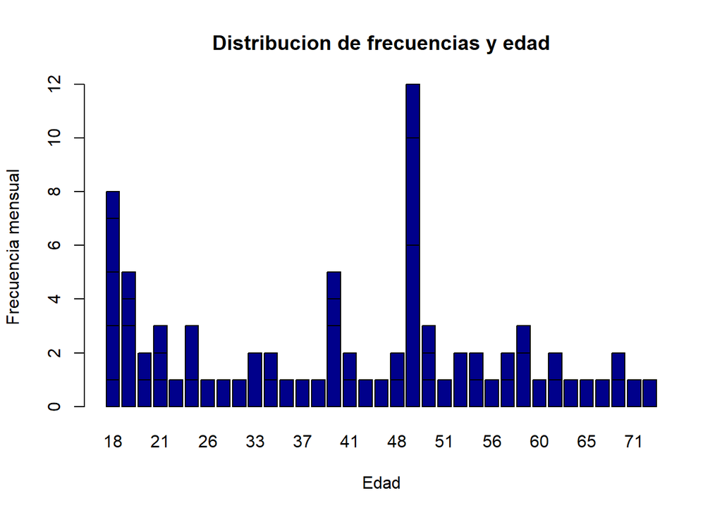

```r
barplot(mec1, main="Distribucion de frecuencias y edad",
  xlab="Edad", col=c("darkblue"),ylab = "Frecuencia mensual")
```

```r
joven<-na.omit(DF$Frecuencia.mensual[which(DF$Edad<35)])
mean(joven)
```

```
## [1] NA
```

```r
adulto<-na.omit(DF$Frecuencia.mensual[which(DF$Edad<56,DF$Edad>35)])
mean(adulto)
```

```
## [1] NA
```

```r
adultomayor<-na.omit(DF$Frecuencia.mensual[which(DF$Edad>56)])
mean(adultomayor)
```

```
## [1] NA
```